# Movie Day

13 mars 2023

## TABLE DES MATIERES

- Description du projet
- Explication du code
- Difficultes
- Fonctions non utilisees
- Comment se simplifier la vie ?
- Auteurs

## DESCRIPTION DU PROJET

Le projet **Movie day** a pour objectif d’aider les cinephiles lorsqu’ils souhaitent aller au cinema dans la journee.

Il suffit d’indiquer au programme quel est le cinema de Strasbourg que vous preferez et le jour que vous voulez consacrer en “Movie Day” et le programme vous indiquera tous les films de la journee, en VO et en VF ainsi que leurs differentes seances.

Vous pourrez finalement, dans un temps reduit, faire votre choix entre toutes les seances qui s’affichent sur votre terminal.

Il est essentiel pour faire fonctionner le programme d’avoir acces a un environnement qui peut lire du python et d’avoir un navigateur base sur Chromium.

## EXPLICATION DU CODE

- Utilisation de BeautifulSoup pour commencer
- Utilisation de Selenium
- Puis lien entre dates, horaires et nom du film grace a l’identifiant du film

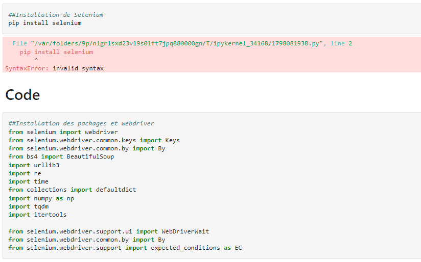

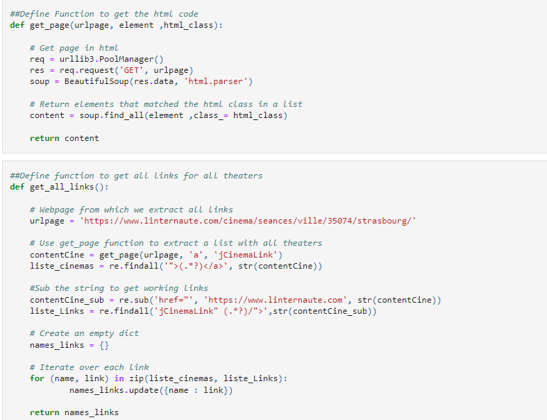

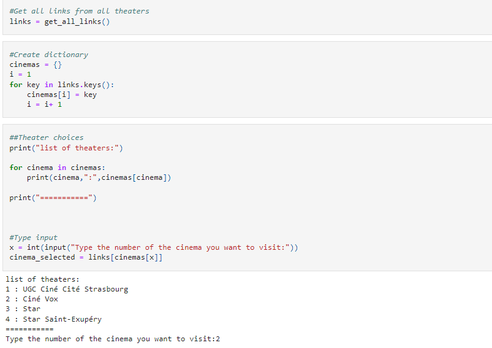

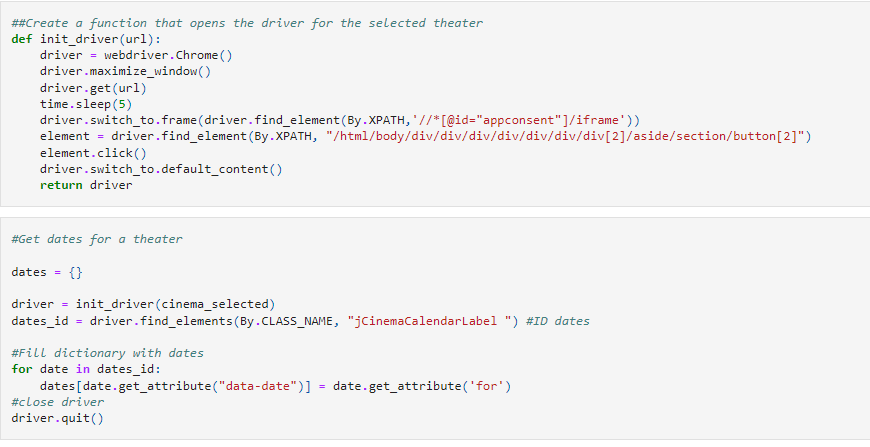

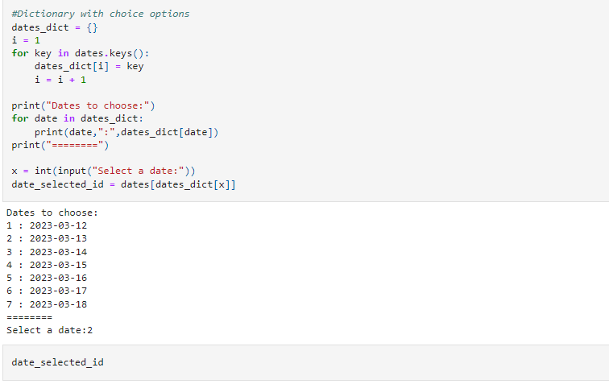

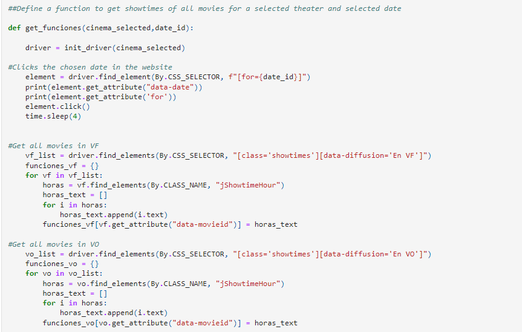

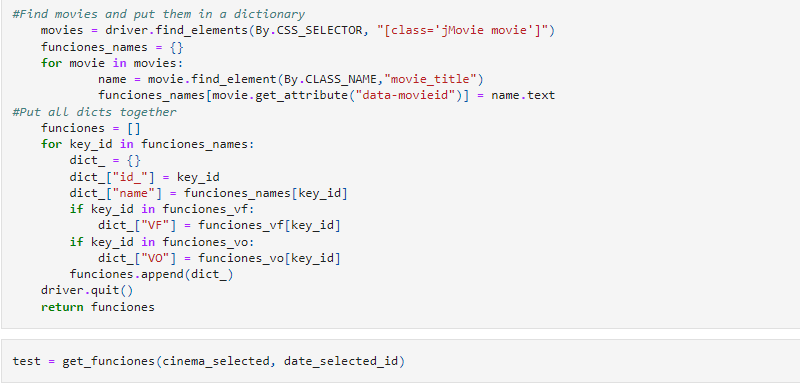

## DIFFICULTES

- Inspiration du code sur les RU avec Beautiful Soup -> Probleme parce qu’il s’agissait d’une page dynamique -> alors utilisation de Selenium avec un webdriver
- Difficile de matcher les horaires, les vf, les vo et les noms

## FONCTIONS NON UTILISEES

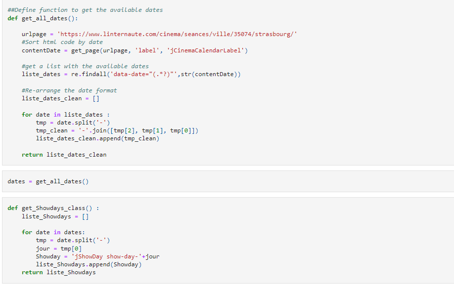

## COMMENT SE SIMPLIFIER LA VIE

- Si nous avions commence avec Selenium directement !
- Tourner le programme differemment, avec par exemple la demande d’une heure precise dans un cinema et l’affichage de tous les films qui passent a cette heure-ci.

## AUTEURS

Marc FROEHLICH - M1 SE

Andre MIRANDA - M1 SE

Jeanne PETIT-DANGEON - M1 DS2E